# Propensity Score Matching Tutorial

Hans Elliott

5/2/2022

**Propensity Score Matching tutorial:**  
This notebook pulls from this nice tutorial from Netflix data scientist [Simon Ejdemyr](https://sejdemyr.github.io/), and elaborates by developing a more elaborate model to estimate propensity scores and trying multiple matching algorithms.

```r
library(pacman)
p_load(here,     ##for loading data
       MatchIt,  ##for
       fixest, broom, ##for regression and tidy results
       ggplot2, kableExtra, ##for plots and tables
       dplyr, data.table ##for general manipulation
       )
```

Data from the Early Childhood Longitudinal Study (ECLS), for the United States. The tutorial focuses on the effect of going to Catholic school, as opposed to public school, on student achievement. (See propensity_score_matching_ex/data-processing.R) for data processing).

```r
##Data
ecls = here("R_notebooks/propensity_score_ex", "ecls-processed.csv") %>%
        fread()
dim(ecls); names(ecls)
```

```
## [1] 11078    23
```

```
##  [1] "V1"            "childid"       "catholic"      "race"
##  [5] "race_white"    "race_black"    "race_hispanic" "race_asian"
##  [9] "p5numpla"      "p5hmage"       "p5hdage"       "w3daded"
## [13] "w3momed"       "w3daded_hsb"   "w3momed_hsb"   "w3momscr"
## [17] "w3dadscr"      "w3inccat"      "w3income"      "w3povrty"
## [21] "p5fstamp"      "c5r2mtsc"      "c5r2mtsc_std"
```

## Analyzing Pure Difference in Means

```r
ecls[,
     .(n_students = .N,
       mean_math = mean(c5r2mtsc_std)),
     by = .(catholic)] %>%
   .[,
     .(catholic=catholic,n_students=n_students, mean_math_score=mean_math,
       std_error = sd(ecls$c5r2mtsc_std) / sqrt(n_students))]
```

```
##    catholic n_students mean_math_score  std_error
##       <int>      <int>           <num>      <num>
## 1:        0       9568     -0.03059583 0.01022326
## 2:        1       1510      0.19386817 0.02573425
```

We can also test the statistical significance of the difference of means using a t-test. We get a small p-value, indicating statistical significance.

```r
t.test(ecls$c5r2mtsc_std ~ ecls$catholic)
```

```
##
##  Welch Two Sample t-test
##
## data:  ecls$c5r2mtsc_std by ecls$catholic
## t = -9.1069, df = 2214.5, p-value < 2.2e-16
## alternative hypothesis: true difference in means between group 0 and group 1 is not equal to 0
## 95 percent confidence interval:
##  -0.2727988 -0.1761292
## sample estimates:
## mean in group 0 mean in group 1
##     -0.03059583      0.19386817
```

We could also just run a simple regression:

```r
naive_reg = lm(c5r2mtsc_std ~ catholic, data = ecls)
tidy(naive_reg)
```

```
## # A tibble: 2 x 5
##   term        estimate std.error statistic  p.value
##   <chr>          <dbl>     <dbl>     <dbl>    <dbl>
## 1 (Intercept)  -0.0306    0.0102     -3.00 2.69e- 3
## 2 catholic      0.224     0.0276      8.13 4.75e-16
```

Now we’ll look at the difference in means for some example covariates. This will help provide evidence as to why the naive difference in means is not a true effect - that is, it will reveal that we have some confounding variables biasing the results. This is essentially a balance test (as in a RCT) where `catholic` is our treatment variable (which, as we see below, is far from randomly assigned). From the tutorial: - `race_white`: Is the student white (1) or not (0)?  
- `p5hmage`: Mother’s age  
- `w3income`: Family income  
- `p5numpla`: Number of places the student has lived for at least 4 months  
- `w3momed_hsb`: Is the mother’s education level high-school or below (1) or some college or more (0)?

In the tutorial, the author does a bunch of t tests (like we did above), but I’ll take advantage of `fixest::feols`’s ability to take multiple outcome variables in one formula.  
We can see that *all* of these covariates are significantly correlated with `catholic`, demonstrating selection bias.

```r
# library(fixest)
ecls_cov = c('race_white', 'p5hmage', 'w3income', 'p5numpla', 'w3momed_hsb')

cov_balance = fixest::feols(
                    c(race_white, p5hmage, w3income, p5numpla, w3momed_hsb) ~
                                catholic, data = ecls)

cov_balance
```

```
## Standard-errors: IID
## Dep. var.: race_white
##             Estimate Std. Error  t value  Pr(>|t|)
## (Intercept) 0.556125   0.005013 110.9442 < 2.2e-16 ***
## catholic    0.169041   0.013577  12.4504 < 2.2e-16 ***
## ---
## Dep. var.: p5hmage
##             Estimate Std. Error  t value  Pr(>|t|)
## (Intercept) 37.56097   0.071185 527.6510 < 2.2e-16 ***
## catholic     2.01419   0.186611  10.7935 < 2.2e-16 ***
## ---
## Dep. var.: w3income
##             Estimate Std. Error  t value  Pr(>|t|)
## (Intercept)  54889.2    484.174 113.3666 < 2.2e-16 ***
## catholic     27185.1   1276.539  21.2960 < 2.2e-16 ***
## ---
## Dep. var.: p5numpla
##              Estimate Std. Error   t value   Pr(>|t|)
## (Intercept)  1.132669   0.004307 263.01376  < 2.2e-16 ***
## catholic    -0.039969   0.011342  -3.52391 0.00042723 ***
## ---
## Dep. var.: w3momed_hsb
##              Estimate Std. Error  t value  Pr(>|t|)
## (Intercept)  0.464092   0.005420  85.6185 < 2.2e-16 ***
## catholic    -0.236885   0.014201 -16.6807 < 2.2e-16 ***
```

## Propensity Score Estimation

Estimate the propensity score by running a logit model, with the treatment status (a binary variable) as the dependent variable. We also include any covariate related to both treatment assignment and potential outcomes (ie, confounders).  
I write the formula in an easily modifiable format so I can experiment with different covariates. Family = “binomial” links to a logit model,

```r
ecls_cov = c('race_white', 'p5hmage', 'w3income', 'p5numpla', 'w3momed_hsb')

prop_score_formula = paste("catholic", "~", paste(ecls_cov, collapse = " + "))

ps_mod = glm(as.formula(prop_score_formula),
              family = "binomial", data = ecls)
```

Now we estimate the propensity score for each student (observation) in the data. This is just the predicted probability of being treated, given the estimated model’s parameters. We use predict with type = “response” so that the output is at the level of the response variable (a predicted probability between 0 and 1).

```r
ps_df = data.frame(prop_score = predict(ps_mod, type = "response"),
                   catholic = ps_mod$model$catholic)
  #(extract observations used in model, so obs. with missing values get dropped)

head(ps_df)
```

```
##   prop_score catholic
## 1  0.2292928        0
## 2  0.1801360        0
## 4  0.2092957        0
## 5  0.2154022        1
## 6  0.3604931        0
## 7  0.1080608        0
```

## Examining Region of Common Support

In addition to the Conditional Independence Assumption, a key assumption in matching methods is the Common Support, or Overlap, Assumption. In order for matching methods to work, we need to be able to estimate treated vs untreated differences for all values of X (the covariates). With propensity score matching, this is simplified since our covariates are essentially collapsed into a single covariate - the propensity score. We can inspect visually to see if individuals exist at each of the (bins of) propensity score levels.

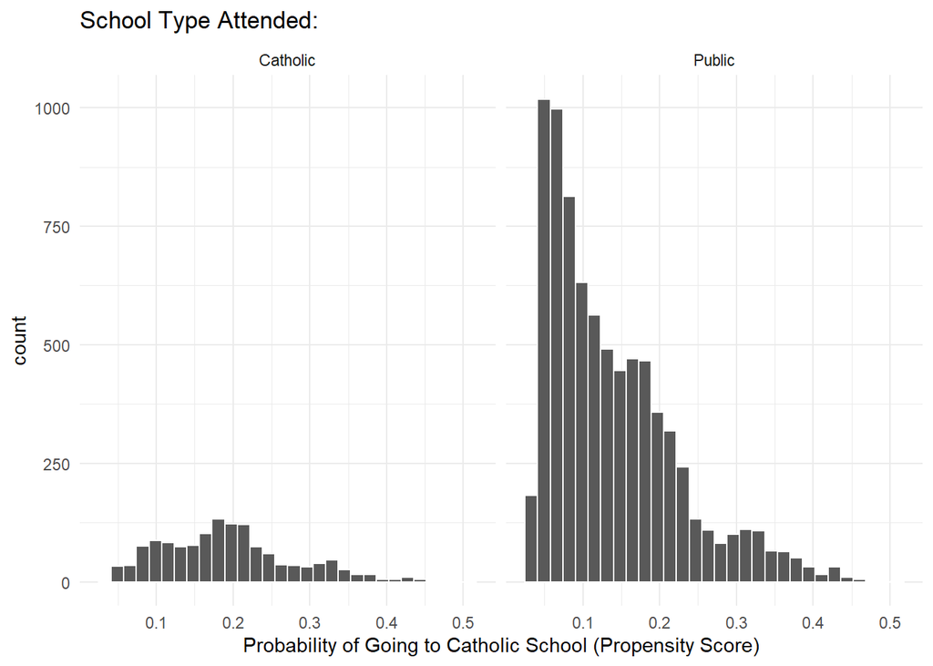

```r
##Create histogram
ps_df %>%
  mutate(catholic = ifelse(catholic == 1, "Catholic", "Public")) %>%
  ggplot(aes(x = prop_score)) +
    geom_histogram(color = "white") +
    facet_wrap(~catholic) +
    labs(title = "School Type Attended:",
         x = "Probability of Going to Catholic School (Propensity Score)") +
    theme_minimal()
```

We can see that we have overlap in most of these bins.

## The Matching Algorithm

We use a matching algorithm from the `matchit` package which finds pairs of observations with very similar propensity scores but different treatment statuses. `matchit` estimates the propensity scores itself, so we just need to provide the right formula.

```r
##remove missing values, which matchit does not accept
ecls_complete = ecls %>%
  select(c5r2mtsc_std, any_of(ecls_cov), catholic) %>%
  na.omit()

##model using nearest neighbors matching algorithm
mod_match = MatchIt::matchit(as.formula(prop_score_formula), ##from above
                             method = "nearest", ##use nearest neighbors method
                             data = ecls_complete)

mod_match
```

```
## A matchit object
##  - method: 1:1 nearest neighbor matching without replacement
##  - distance: Propensity score
##              - estimated with logistic regression
##  - number of obs.: 9267 (original), 2704 (matched)
##  - target estimand: ATT
##  - covariates: race_white, p5hmage, w3income, p5numpla, w3momed_hsb
```

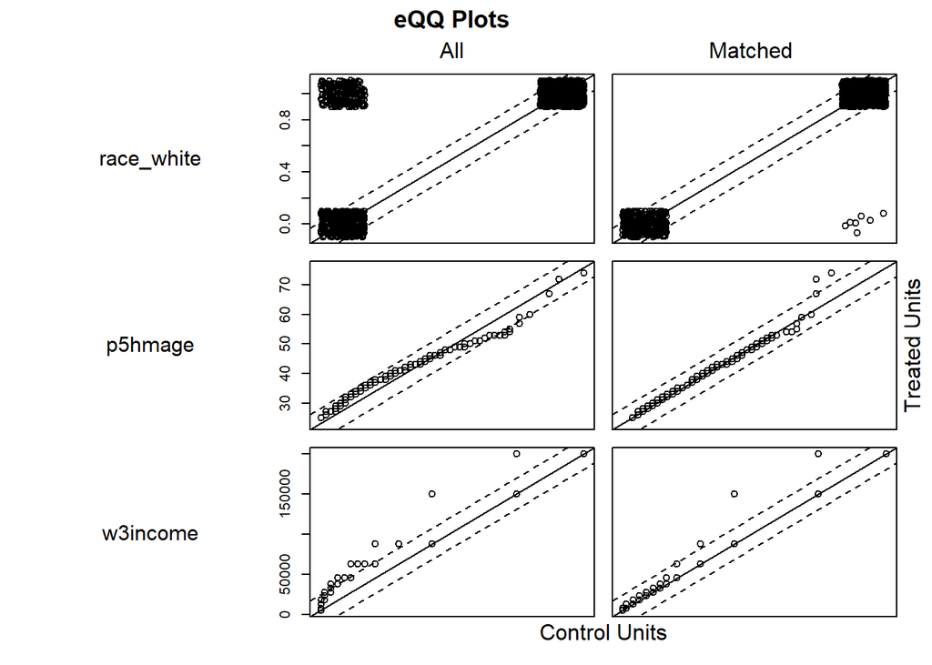

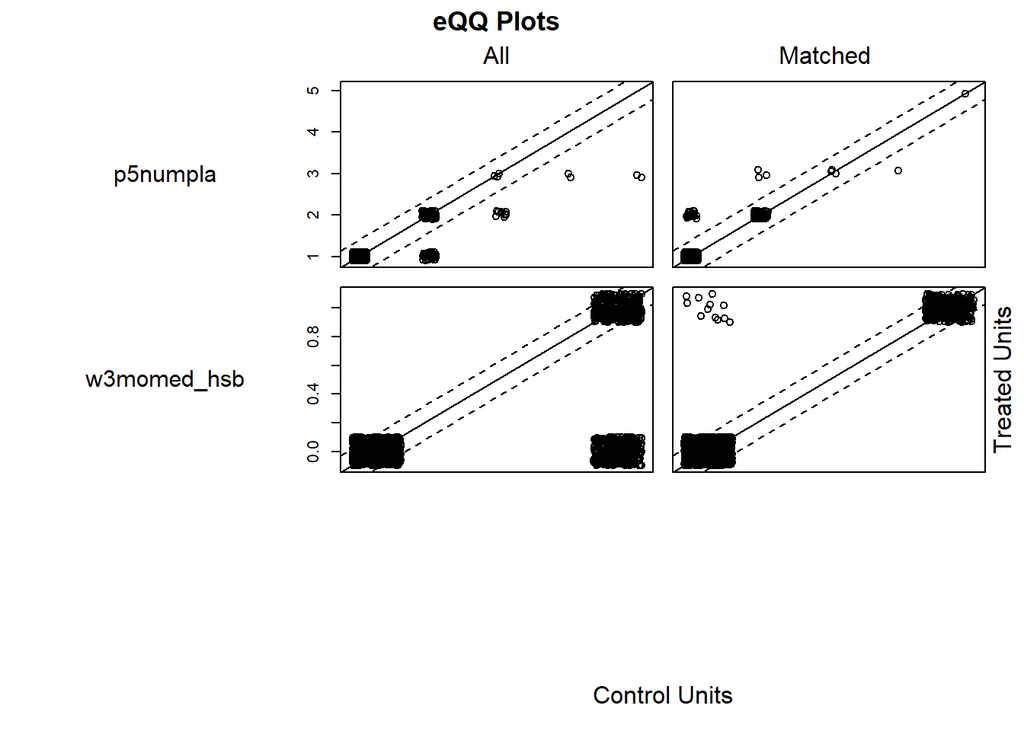

```r
plot(mod_match)
```

```r
## create dataframe with only the matched obs (note, 'distance' = prop. score)
ecls_matched = MatchIt::match.data(mod_match)
dim(ecls_matched); head(ecls_matched)
```

```
## [1] 2704   10
```

```
##    c5r2mtsc_std race_white p5hmage w3income p5numpla w3momed_hsb catholic
##           <num>      <int>   <int>    <num>    <int>       <int>    <int>
## 1:    0.9817533          1      47  62500.5        1           0        0
## 2:    0.5943775          1      41  45000.5        1           0        0
## 3:    0.4906106          1      43  62500.5        1           0        0
## 4:    1.4512779          1      38  87500.5        1           0        1
## 5:    2.5956991          1      47 150000.5        1           0        0
## 6:    0.3851966          1      41  62500.5        1           0        0
##     distance weights subclass
##        <num>   <num>   <fctr>
## 1: 0.2292928       1      912
## 2: 0.1801360       1       56
## 3: 0.2092957       1     1344
## 4: 0.2154022       1      671
## 5: 0.3604931       1      881
## 6: 0.1997897       1      128
```

# Examining covariate balance in the matched sample

## Visually

If our treatment and control groups (catholic vs public school) are balanced, then when we plot the covariates alongside the propensity score, the means should be practically identical. Since there are a lot of observations at each interval, a loess smoother will help visualize the covariate balance.

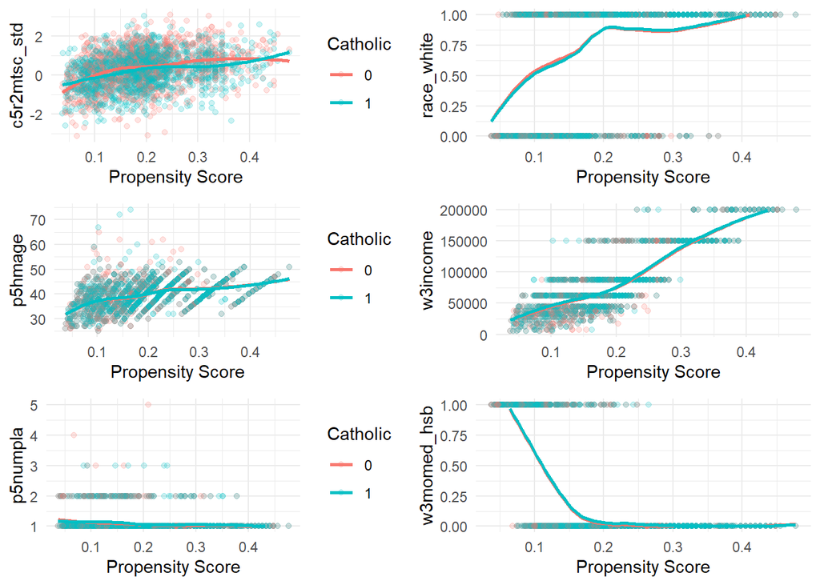

```r
fn_plot_balances = function(df, variable){
  df$variable = df %>% select(variable)

  y_lims = c(min(df$variable), max(df$variable))

  ggplot(data = df,
         aes(x = distance, y = variable,
             color = as.factor(catholic))) +
    geom_point(alpha = 0.2) +
    geom_smooth(method = "loess", se  = F) +
    ylim(y_lims) +
    ylab(variable) + xlab("Propensity Score") +
    labs(color = "Catholic") +
    theme_minimal()

}


library(gridExtra)
grid.arrange(
  fn_plot_balances(ecls_matched, "c5r2mtsc_std"),
  fn_plot_balances(ecls_matched, "race_white")+theme(legend.position = "none"),
  fn_plot_balances(ecls_matched, "p5hmage"),
  fn_plot_balances(ecls_matched, "w3income")+theme(legend.position = "none"),
  fn_plot_balances(ecls_matched, "p5numpla"),
  fn_plot_balances(ecls_matched, "w3momed_hsb")+theme(legend.position = "none"),
    nrow = 3
)
```

## Through difference in means

As before, we can compare the covariate means of the treatment/control groups and determine if there are statistically significant differences. We can see that for all variables but `c5r2mtsc_std` (a standardized math score), there is no statistically significant difference between the treatment and control group mean. For `c5r2mtsc_std`, catholic school students’ mean score is -0.15 standard deviations lower than the public school students’ mean.

```r
ps_balance = fixest::feols(
       c(c5r2mtsc_std, race_white, p5hmage, w3income, p5numpla, w3momed_hsb) ~
                                catholic, data = ecls_matched)


ps_balance
```

```
## Standard-errors: IID
## Dep. var.: c5r2mtsc_std
##              Estimate Std. Error  t value   Pr(>|t|)
## (Intercept)  0.359367   0.024822 14.47779  < 2.2e-16 ***
## catholic    -0.149699   0.035104 -4.26450 2.0723e-05 ***
## ---
## Dep. var.: race_white
##              Estimate Std. Error   t value  Pr(>|t|)
## (Intercept)  0.747041   0.011872 62.924821 < 2.2e-16 ***
## catholic    -0.005917   0.016789 -0.352432   0.72454
## ---
## Dep. var.: p5hmage
##              Estimate Std. Error    t value  Pr(>|t|)
## (Intercept) 39.550296   0.142208 278.116405 < 2.2e-16 ***
## catholic     0.042899   0.201112   0.213311    0.8311
## ---
## Dep. var.: w3income
##             Estimate Std. Error   t value  Pr(>|t|)
## (Intercept) 81403.99    1271.45 64.024651 < 2.2e-16 ***
## catholic     1164.94    1798.10  0.647875   0.51712
## ---
## Dep. var.: p5numpla
##             Estimate Std. Error   t value  Pr(>|t|)
## (Intercept) 1.076183   0.008202 131.20300 < 2.2e-16 ***
## catholic    0.015533   0.011600   1.33901   0.18068
## ---
## Dep. var.: w3momed_hsb
##             Estimate Std. Error   t value  Pr(>|t|)
## (Intercept) 0.215237   0.011257 19.120541 < 2.2e-16 ***
## catholic    0.008136   0.015920  0.511075   0.60934
```

### 4.3 Average absolute standardized difference

```r
match_summary = summary(mod_match)$sum.matched
```